# MTH6139 Time Series

Coursework 1 - NASDAQ Composite Index

Karla Velazco Casanas - 231175355

March Midterm 2026

# Introduction

In this report, the Prophet model is used to analyse and forecast the Nasdaq Composite index (NCI). This index reflects the performance of a large number of companies listed on the Nasdaq stock exchange.

The aim is to take the raw data prepare it properly and then use a forecasting model to understand how the index might behave in the near future.

The dataset contains daily values of the index over roughly five years.

## Why I Chose This Dataset

I chose the NCI as it is widely followed and gives a good representation of how major companies perform over time. Understanding how these companies behave is important from an economic perspective as it reflects overall market conditions and investor confidence.

I also find it particularly interesting given the recent economic shifts and uncertainty which have had a noticeable impact on financial markets.

# Understanding the Dataset

The data for this project was taken from the FRED database *. After downloading it, the file was imported into R as a CSV from the data folder. It includes the date of each observation and the corresponding value of the index.

## What the Data Looks Like

```r
nasdaq_data = read.csv("data/nasdaq.csv")

head(nasdaq_data)
```

```
##   observation_date NASDAQCOM
## 1       2021-03-17  13525.20
## 2       2021-03-18  13116.17
## 3       2021-03-19  13215.24
## 4       2021-03-22  13377.54
## 5       2021-03-23  13227.70
## 6       2021-03-24  12961.89
```

After importing the file we can see that the dataset has the expected structure and is ready to be processed.

## Preparing the Data for Prophet

Prophet requires the data to follow a specific format so some adjustments need to be made. The date column is converted into a proper date format and renamed `ds`, while the index values are stored in a column called `y`.

Any missing values are also removed to avoid issues when fitting the model.

```r
nasdaq_prophet_data = data.frame(
  ds = as.Date(nasdaq_data$observation_date),
  y = nasdaq_data$NASDAQCOM
)

nasdaq_prophet_data = na.omit(nasdaq_prophet_data)
```

At this point, the dataset is ready to be used with Prophet!

# Understanding the Time Series

Before applying any model it makes sense to first look at the data. This helps highlight the main behaviour of the series and gives a better idea of what kind of model might work well.

## Movement of the Index Over Time

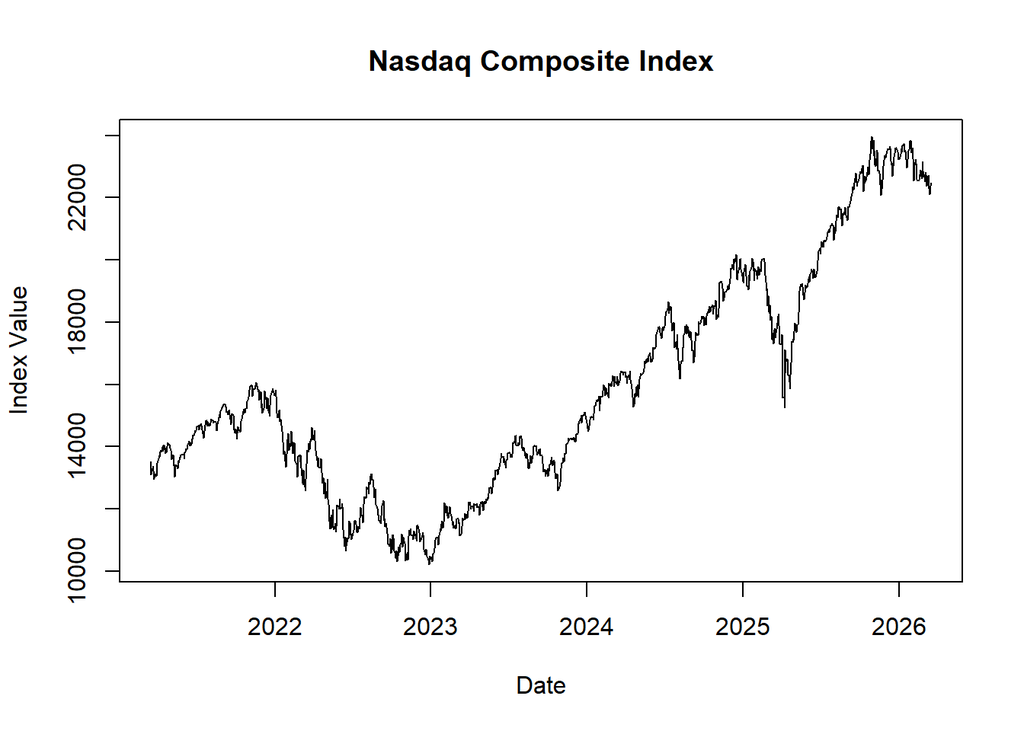

```r
plot(
  nasdaq_prophet_data$ds,
  nasdaq_prophet_data$y,
  type = "l",
  main = "Nasdaq Composite Index",
  xlab = "Date",
  ylab = "Index Value"
)
```

Looking at the plot, the index generally increases over time, although it does not move in a smooth way. There are frequent ups and downs, which is typical for financial data.

There are also a few noticeable drops where the index falls quite quickly before picking up again showing that the market can change quite quickly. Regardless, the overall direction across the full period is clearly upward.

## Linear Trend Estimation

To summarise the general direction of the series a linear model can be fitted using the `lm()` function. This gives a simple idea of how the series is moving on average over time.

```r
time_index = 1:nrow(nasdaq_prophet_data)

nasdaq_linear_model = lm(
  nasdaq_prophet_data$y ~ time_index
)

summary(nasdaq_linear_model)
```

```
##
## Call:
## lm(formula = nasdaq_prophet_data$y ~ time_index)
##
## Residuals:
##     Min      1Q  Median      3Q     Max
## -4222.0 -1910.5   -79.1  2110.3  3840.7
##
## Coefficients:
##              Estimate Std. Error t value Pr(>|t|)
## (Intercept) 1.083e+04  1.254e+02   86.38   <2e-16 ***
## time_index  7.992e+00  1.728e-01   46.25   <2e-16 ***
## ---
## Signif. codes:  0 '***' 0.001 '**' 0.01 '*' 0.05 '.' 0.1 ' ' 1
##
## Residual standard error: 2220 on 1254 degrees of freedom
## Multiple R-squared:  0.6304, Adjusted R-squared:  0.6301
## F-statistic:  2139 on 1 and 1254 DF,  p-value: < 2.2e-16
```

We can also add this fitted trend line to the plot.

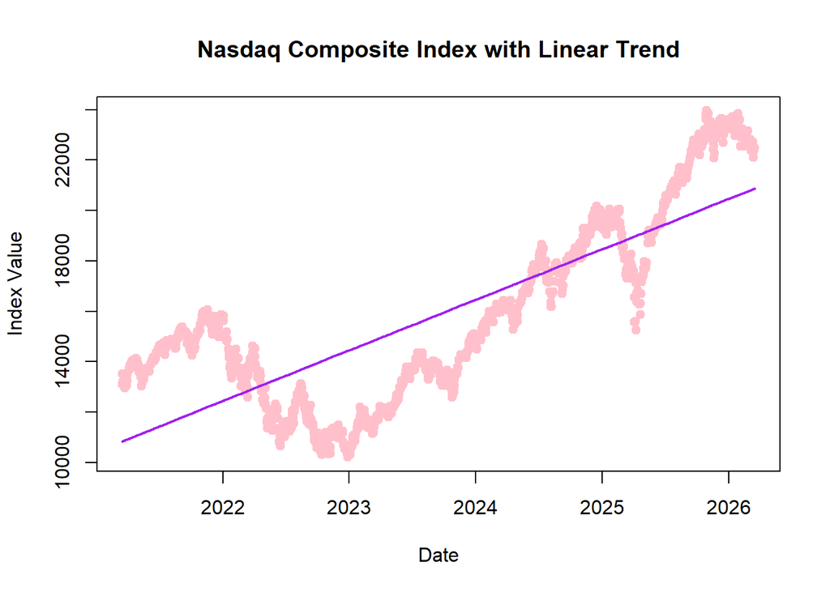

```r
plot(
  nasdaq_prophet_data$ds,
  nasdaq_prophet_data$y,
  main = "Nasdaq Composite Index with Linear Trend",
  xlab = "Date",
  ylab = "Index Value",
  pch = 19,
  col = "pink"
)

lines(
  nasdaq_prophet_data$ds,
  fitted(nasdaq_linear_model),
  col = "purple",
  lwd = 2
)
```

The straight-line fit shows that the series is increasing overall. However, it misses the smaller fluctuations. This suggests a simple linear model is too limited for forecasting.

Since financial data often grows in percentage terms, a log transformation was also considered. In this case it did not noticeably change the forecast, so we use the original data for simplicity.

## Checking for Structure

A Ljung-Box test can be used to check whether the series behaves like random noise.

```r
Box.test(nasdaq_prophet_data$y, type = "Ljung-Box")
```

```
##
##  Box-Ljung test
##
## data:  nasdaq_prophet_data$y
## X-squared = 1251, df = 1, p-value < 2.2e-16
```

The result shows a small p-value indicating that the series is unlikely to be purely random. This is expected as the earlier plot already showed clear patterns and movement over time.

# Forecasting the Nasdaq Composite Index

After exploring the data the next step is to apply the Prophet model to generate forecasts.

## Fitting the Prophet Model

The Prophet package was then used to fit a forecasting model to the prepared Nasdaq data.

```r
library(prophet)

nasdaq_prophet_model = prophet(nasdaq_prophet_data)
```

The model captures the main patterns in the series and is used to produce forecasts for future periods.

## Creating Future Dates

To produce forecasts we first extend the timeline by adding future dates…

```r
nasdaq_future_dates = make_future_dataframe(nasdaq_prophet_model, 8)
```

This creates a dataframe containing the original dates together with 8 future periods.

## Generating the Forecast

The fitted model was then used to generate forecasts for both the existing data and the future dates.

```r
nasdaq_forecast = predict(nasdaq_prophet_model, nasdaq_future_dates)
```

## What Does the Forecast Suggest?

The forecast is now ready to be displayed using the standard Prophet plot!

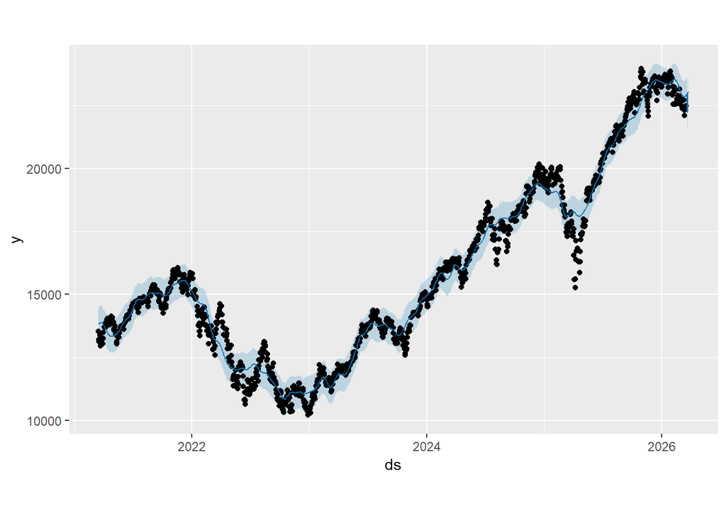

```r
plot(nasdaq_prophet_model, nasdaq_forecast)
```

The black dots represent the observed values, while the blue line shows the fitted values and the forecast. The shaded region gives an idea of how uncertain the predictions are.

The forecast follows the recent behaviour of the series and suggests that the index stays relatively high over the short horizon. However, the uncertainty highlighted reminds us that future values are not guaranteed.

# Overall Findings

The Nasdaq Composite index shows a clear upward trend over time with short-term fluctuations.

A simple linear model gives a simple view of this increase but misses the finer movements in the data. Prophet, on the other hand, provides a more flexible approach and produces a clearer forecast.

The Ljung-Box test confirms that the series contains structure meaning it is suitable for modelling.

Overall Prophet works well for this type of data and provides a useful way to analyse and forecast the movement of the series. The results suggest that the index remains at a relatively high level in the short term although, this should be treated carefully as market conditions can change quickly.

# References

- https://fred.stlouisfed.org/series/NASDAQCOM